# Grid System for COVID-19 Risk Areas

This notebook generates a grid system for counting the number of locations where the risk of the spread of COVID-19 is high.

## Hypotheses

- The greater the number of potentially crowded areas, the higher probability of these areas becoming a cluster
- The areas include:
  - Hawker centres
  - Childcare centres
  - Malls
  - National parks
  - Offices
  - Supermarkets
  - Clinics

## Setup

First, we load the required packages:

```python
# Import required modules
import json
import matplotlib.pyplot as plt
import numpy as np
import pandas as pd
import pickle as pkl
import seaborn as sns
import warnings

from descartes import PolygonPatch
from functools import partial
from geopy.distance import distance
from shapely.geometry import Polygon, Point, LineString
from shapely.ops import transform
from sklearn.preprocessing import MinMaxScaler

# Settings
sns.set_style('whitegrid')
warnings.filterwarnings('ignore')
```

## Functions

Next, we define some helper functions:

```python
def check_grid(pt):
    return df_grid.index[df_grid.grid.apply(lambda x: x.contains(pt))][0]

def c(start, end):
    return list(np.arange(start, end+1))

def check_poly(poly):
    for pa in pa_list:
        for coords in pa_data[pa.upper()]:
            if Polygon(coords).intersects(poly):
                return True

    return False
```

## Obtain Boundaries

We load the planning area geometries in and sort them in order of size:

```python
with open('../Datasets/planning_areas.pkl', 'rb') as handle:
    pa_data = pkl.load(handle)
```

```python
pa_list = ['Bedok', 'Jurong West', 'Tampines', 'Woodlands', 'Hougang',
       'Sengkang', 'Yishun', 'Ang Mo Kio', 'Choa Chu Kang', 'Bukit Merah',
       'Pasir Ris', 'Bukit Batok', 'Bukit Panjang', 'Toa Payoh',
       'Serangoon', 'Geylang', 'Punggol', 'Kallang', 'Queenstown',
       'Clementi', 'Bishan', 'Jurong East', 'Sembawang', 'Bukit Timah',
       'Marine Parade', 'Novena', 'Outram', 'Tanglin', 'Rochor',
       'River Valley', 'Newton', 'Downtown Core', 'Singapore River',
       'Changi', 'Mandai', 'Southern Islands', 'Orchard',
       'Western Water Catchment', 'Sungei Kadut', 'Museum', 'Seletar',
       'Pioneer', 'Lim Chu Kang', 'Tuas', 'North-Eastern Islands',
       'Paya Lebar', 'Boon Lay', 'Tengah', 'Central Water Catchment',
       'Changi Bay', 'Straits View', 'Western Islands', 'Marina East',
       'Marina South', 'Simpang']
```

Next, we compute the boundaries of the Singapore map in terms of minimum and maximum latitude and longitude:

```python
min_lat = 1000
max_lat = 0
min_lon = 1000
max_lon = 0

for pa in pa_list:
    temp_dat = pa_data[pa.upper()]
    temp_coords = np.array([]).reshape(0, 2)
    for coords in temp_dat:
        temp_coords = np.vstack([temp_coords, coords])

    temp_max_lat = np.max(temp_coords[:, 1])
    temp_min_lat = np.min(temp_coords[:, 1])
    temp_max_lon = np.max(temp_coords[:, 0])
    temp_min_lon = np.min(temp_coords[:, 0])

    if temp_min_lat < min_lat:
        min_lat = temp_min_lat
    if temp_max_lat > max_lat:
        max_lat = temp_max_lat

    if temp_min_lon < min_lon:
        min_lon = temp_min_lon
    if temp_max_lon > max_lon:
        max_lon = temp_max_lon
```

These are the results:

```python
# Set values
min_lat = 1.15876249278394
max_lat = 1.47078321261787
min_lon = 103.605664747142
max_lon = 104.088483623514
```

## Plot Grid

Using these boundaries, we define the grid to obtain approximately 750m by 750m grid squares.

```python
# Set coordinates for corners
left_bottom = (min_lon, min_lat)
left_top = (min_lon, max_lat)
right_top = (max_lon, max_lat)
right_bottom = (max_lon, min_lat)

# Set boundaries
bounds = np.array([left_bottom, left_top, right_top, right_bottom, left_bottom])

# Get grid coordinates
cols = np.linspace(min_lon, max_lon, num=73)
rows = np.linspace(min_lat, max_lat, num=47)

# Compute coords for text placement
colshift = cols[1] - cols[0]
rowshift = rows[1] - rows[0]

col_mids = cols + colshift / 10
row_mids = rows + rowshift / 3 * 2

# Check height and width
height = distance((min_lat, min_lon), (rows[1], cols[0])).km
width = distance((min_lat, min_lon), (rows[0], cols[1])).km
```

```python
print('Height: %s km' % round(height, 3))
print('Width: %s km' % round(width, 3))
print('Area: %s sq. km' % str(round(height * width, 3)))
print('No. of Plots: %s' % (cols.shape[0] * rows.shape[0]))
```

```
Height: 0.75 km
Width: 0.746 km
Area: 0.56 sq. km
No. of Plots: 3431
```

That gives us the following gridset:

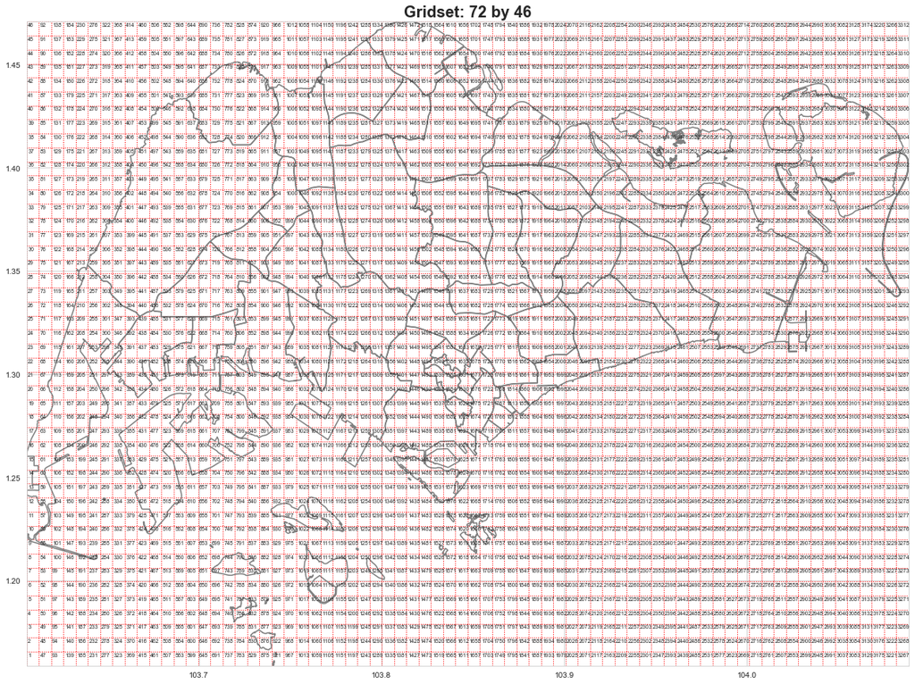

## Extract Grid

Next, we extract all grid coordinates into a data frame. This well help us to assign grids to all coordinates in the dataset containing all locations of interest.

```python
# Initialise dictionary
all_grids = dict()
counter = 0

# Compute grids
for j in range(cols[:-1].shape[0]):
    for i in range(rows[:-1].shape[0]):
        lb = (cols[j], rows[i])
        lt = (cols[j], rows[i+1])
        rt = (cols[j+1], rows[i+1])
        rb = (cols[j+1], rows[i])
        temp_poly = Polygon([lb, lt, rt, rb])
        if check_poly(temp_poly):
            all_grids['grid'+str(counter)] = temp_poly
        counter += 1

# Convert to data frame
df_grid = pd.DataFrame([all_grids], index=['grid']).T
```

## Import Data

We import datasets containing the coordinates for all locations of interest under the following categories:

- Hawker centres (from OneMap)
- Childcare centres (from OneMap)
- Malls (from SGCarMart)
- National parks (from OneMap)
- Offices (from SGCarMart)
- Supermarkets (from OneMap)
- Clinics (from MOH)

### Hawker Centres

```python
# Hawker centres
hawker = pd.read_csv('../Datasets/loc_hawker_centres.csv')
hawker =  hawker[['lat', 'lon']]
hawker['category'] = 'hawker'
```

### Childcare Centres

```python
# Childcare
childcare = pd.read_csv('../Datasets/loc_childcare.csv')
childcare = childcare[['lat', 'lon']]
childcare['category'] = 'childcare'
```

### Malls

```python
# Malls
malls = pd.read_csv('../Datasets/loc_malls.csv')
malls = malls[['lat', 'lon']]
malls['category'] = 'mall'
```

### National Parks

```python
# National parks
nparks = pd.read_csv('../Datasets/loc_national_parks.csv')
nparks = nparks[['lat', 'lon']]
nparks['category'] = 'npark'
```

### Offices

```python
# Offices
offices = pd.read_csv('../Datasets/loc_offices.csv')
offices = offices[['lat', 'lon']]
offices['category'] = 'office'
```

### Supermarkets

```python
# Supermarkets
supermarkets = pd.read_csv('../Datasets/loc_supermarkets.csv')
supermarkets = supermarkets[['lat', 'lon']]
supermarkets['category'] = 'supermarket'
```

### Clinics

```python
# Clinics
clinics = pd.read_csv('../Datasets/loc_clinics.csv')
clinics = clinics[['lat', 'lon']]
clinics['category'] = 'clinics'
```

### Merging of Data

We merge all the data into a single dataset, and assign a grid number to all locations according to location (latitude/longitude).

```python
# Merge
loc_df = pd.concat([
    hawker, childcare, malls, nparks, offices, supermarkets, clinics
]).reset_index(drop=True)

# Add points
loc_df['pt'] = loc_df[['lat', 'lon']].apply(lambda x: Point((x['lon'], x['lat'])), axis=1)

# Compute grid
loc_df['grid'] = loc_df.pt.apply(check_grid)

# Display data
loc_df.head()
```

|  | lat | lon | category | pt | grid |
| --- | --- | --- | --- | --- | --- |
| 0 | 1.389152 | 103.988246 | hawker | POINT (103.988245749103 1.38915172065006) | grid2655 |
| 1 | 1.364229 | 103.866536 | hawker | POINT (103.866536130299 1.36422852315868) | grid1778 |
| 2 | 1.375429 | 103.882978 | hawker | POINT (103.882977999397 1.37542896666561) | grid1917 |
| 3 | 1.327850 | 103.887129 | hawker | POINT (103.887128535137 1.32784956142548) | grid1910 |
| 4 | 1.323445 | 103.885449 | hawker | POINT (103.885449224256 1.32344525333847) | grid1910 |

## Compute Entity Counts

This first block of code obtains the counts and also creates a total count for all entities.

```python
# Compute counts per grid
loc_counts = loc_df.groupby(['grid', 'category'])[['category']].count().rename(columns={'category': 'counts'}).reset_index()
loc_counts = loc_counts.pivot_table(index='grid', columns='category', values='counts', aggfunc='sum')
loc_counts['total'] = loc_counts[['childcare', 'office', 'hawker', 'npark', 'mall', 'supermarket', 'clinics']].sum(axis=1)
```

```python
# Initialise scaler
mms = MinMaxScaler(feature_range=(0.0,0.6))

# Separate grids
grid_hawker = loc_counts[['hawker']].copy().rename(columns={'hawker': 'vals'})
grid_hawker = pd.DataFrame(mms.fit_transform(np.log1p(grid_hawker[['vals']])), index=grid_hawker.index, columns=['vals'])

grid_childcare = loc_counts[['childcare']].copy().rename(columns={'childcare': 'vals'})
grid_childcare = pd.DataFrame(mms.fit_transform(np.log1p(grid_childcare[['vals']])), index=grid_childcare.index, columns=['vals'])

grid_mall = loc_counts[['mall']].copy().rename(columns={'mall': 'vals'})
grid_mall = pd.DataFrame(mms.fit_transform(np.log1p(grid_mall[['vals']])), index=grid_mall.index, columns=['vals'])

grid_npark = loc_counts[['npark']].copy().rename(columns={'npark': 'vals'})
grid_npark = pd.DataFrame(mms.fit_transform(np.log1p(grid_npark[['vals']])), index=grid_npark.index, columns=['vals'])

grid_offices = loc_counts[['office']].copy().rename(columns={'office': 'vals'})
grid_offices = pd.DataFrame(mms.fit_transform(np.log1p(grid_offices[['vals']])), index=grid_offices.index, columns=['vals'])

grid_supermarket = loc_counts[['supermarket']].copy().rename(columns={'supermarket': 'vals'})
grid_supermarket = pd.DataFrame(mms.fit_transform(np.log1p(grid_supermarket[['vals']])), index=grid_supermarket.index, columns=['vals'])

grid_clinics = loc_counts[['clinics']].copy().rename(columns={'clinics': 'vals'})
grid_clinics = pd.DataFrame(mms.fit_transform(np.log1p(grid_clinics[['vals']])), index=grid_clinics.index, columns=['vals'])

grid_total = loc_counts[['total']].copy().rename(columns={'total': 'vals'})
grid_total = pd.DataFrame(mms.fit_transform(np.log1p(grid_total[['vals']])), index=grid_total.index, columns=['vals'])
```

## Grid Plots

Scroll below to see the grid plots for entity counts for each location type. The stronger the colour, the more entities of that type in that particular grid square.

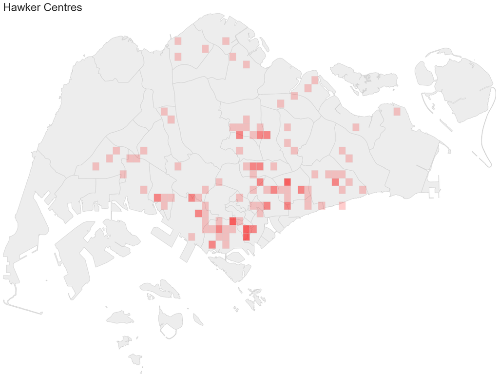

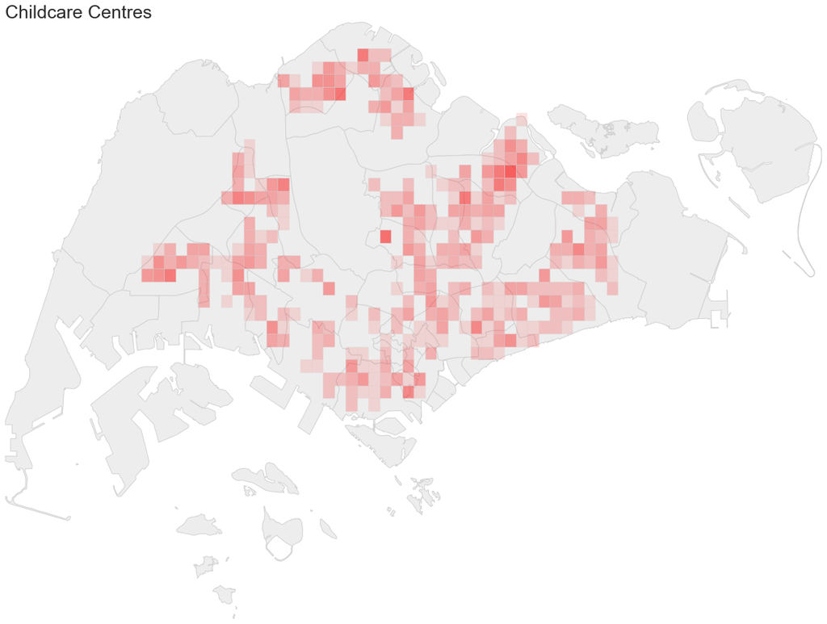

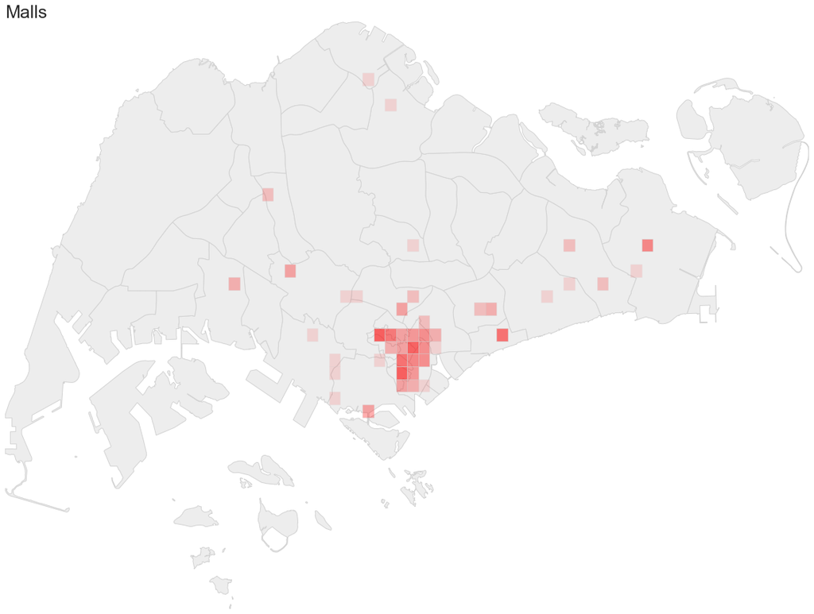

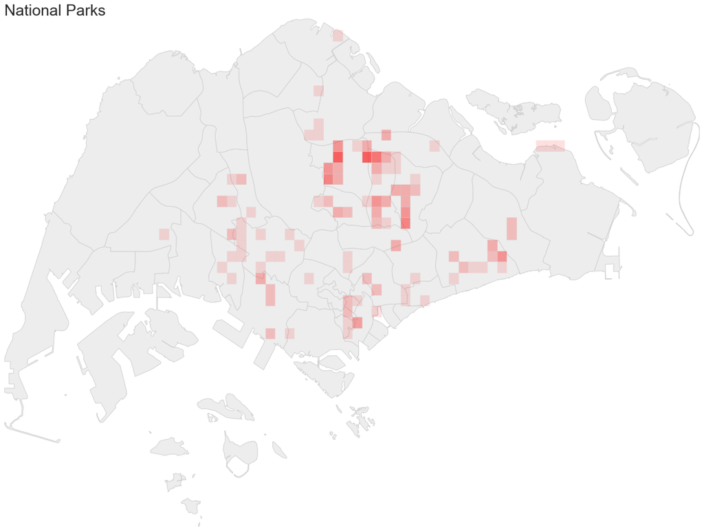

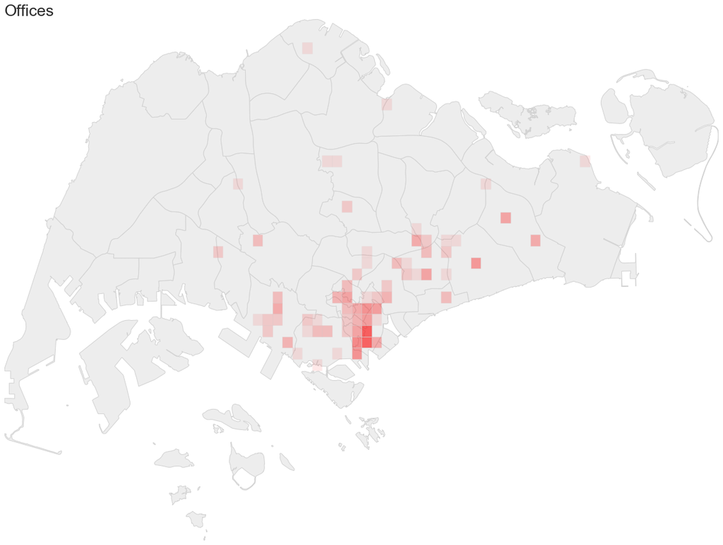

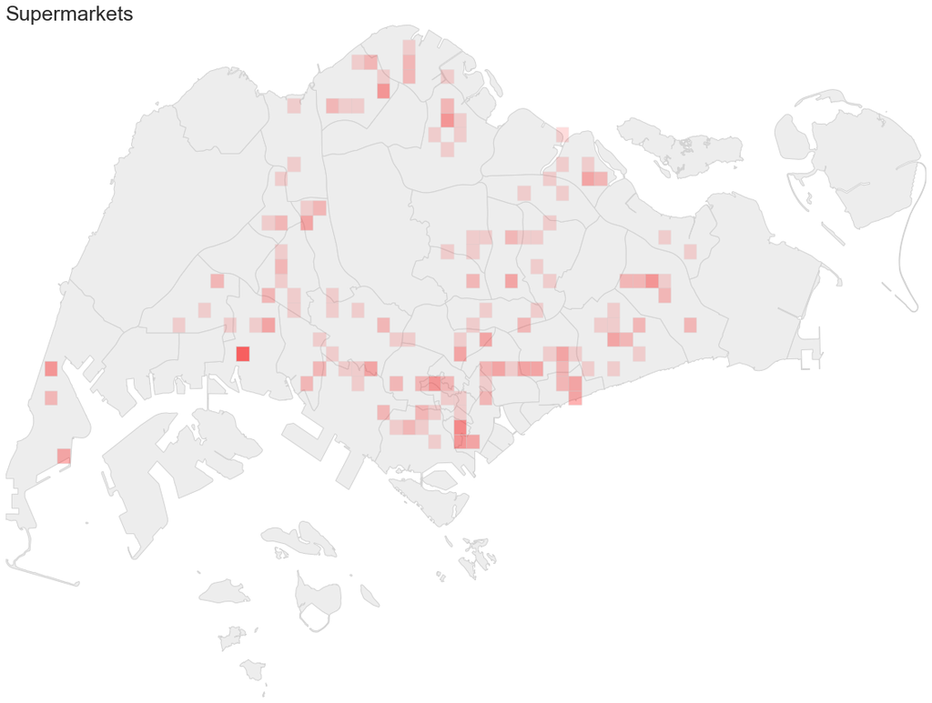

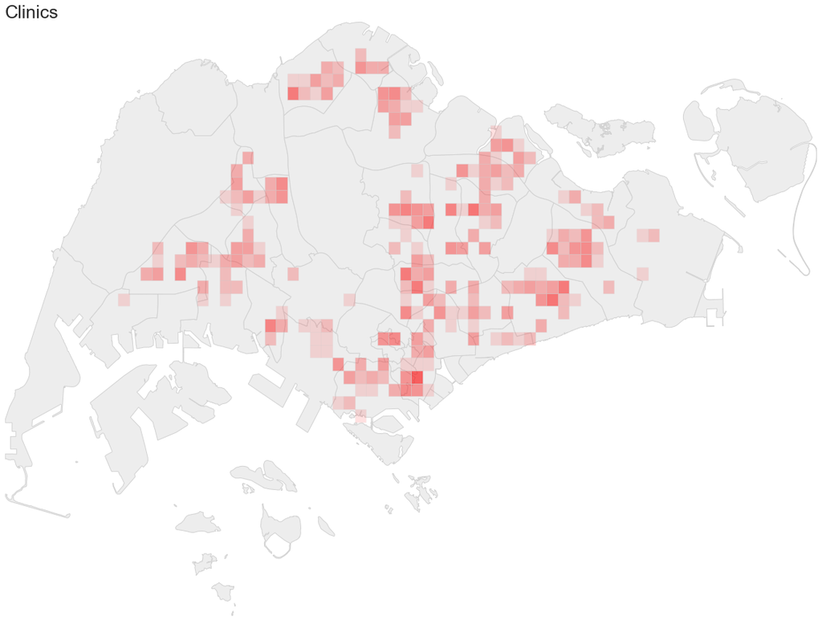

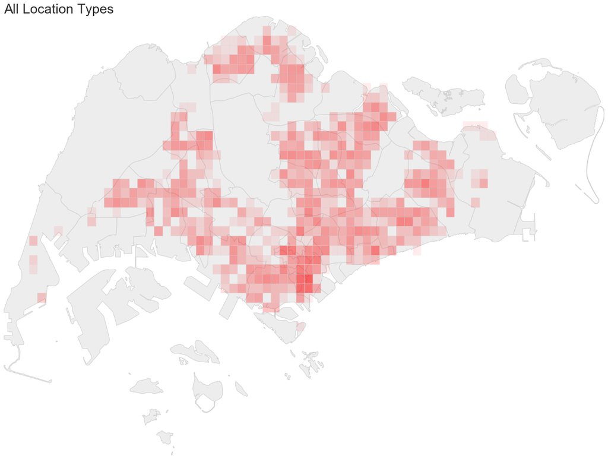